# Matt Melnychuk’s Midterm for R 421

## II. Data Visualization

Continue with the data from part I.

*Notice:* I first wanted to change the coded variables so that they are easier to understand in the visuals.

```r
library(tidyverse)
df2$hospital <- case_when(
  df2$provider == '7201' ~ 'Newport',
  df2$provider == '7202' ~ 'St. Joseph',
  df2$provider == '7203' ~ 'Memorial',
  df2$provider == '7204' ~ 'Miriam',
  df2$provider == '7205' ~ 'Rhode Island Hospital',
  df2$provider == '7206' ~ 'Roger Williams',
  df2$provider == '7209' ~ 'South County',
  df2$provider == '7210' ~ 'Kent County',
  df2$provider == '7211' ~ 'Westerly',
  df2$provider == '7212' ~ 'Rehab of RI',
  df2$provider == '7213' ~ 'Landmark Medical Center',
  df2$provider == '7214' ~ 'Women and Infants',
  df2$provider == '7215' ~ 'Bradley',
  df2$provider == '7216' ~ 'Butler',
  TRUE ~ '')

df2$RE2 <- case_when(
  df2$raceethn == '1' ~ 'White',
  df2$raceethn == '2' ~ 'Black',
  df2$raceethn == '3' ~ 'Asian',
  df2$raceethn == '4' ~ 'American Indian',
  df2$raceethn == '5' ~ 'Native Hawaiian',
  df2$raceethn == '6' ~ 'Other',
  df2$raceethn == '7' ~ 'Hispanic',
  df2$raceethn == '9' ~ 'Unknown',
  TRUE ~ '')

df2$SEX2 <- case_when(
  df2$sex == '1' ~ 'Male',
  df2$sex == '2' ~ 'Female',
  TRUE ~ 'Unknown')

df2$Camp2 <- case_when(
  df2$campus == '1' ~ 'St. Joseph - Fatima',
  df2$campus == '2' ~ 'St. Joseph - Specialty',
  df2$campus == '3' ~ 'RI Adult',
  df2$campus == '4' ~ 'RI Hasbro',
  df2$campus == '0' ~ 'Only Campus',
  TRUE ~ '')

df2$Admit2 <- case_when(
  df2$admtype == '1' ~ 'Emergency',
  df2$admtype == '2' ~ 'Urgent',
  df2$admtype == '3' ~ 'Electric',
  df2$admtype == '4' ~ 'Newborn',
  df2$admtype == '5' ~ 'Trauma',
  df2$admtype == '9' ~ 'Unknown',
  TRUE ~ '')
```

1. Provides at least 10 meaningful plots. Comments on the plots. All plots should have title, caption, appropriate labels on x and y-axis

### Do Hospitals Specialize?

#### Age by Hospital (1):

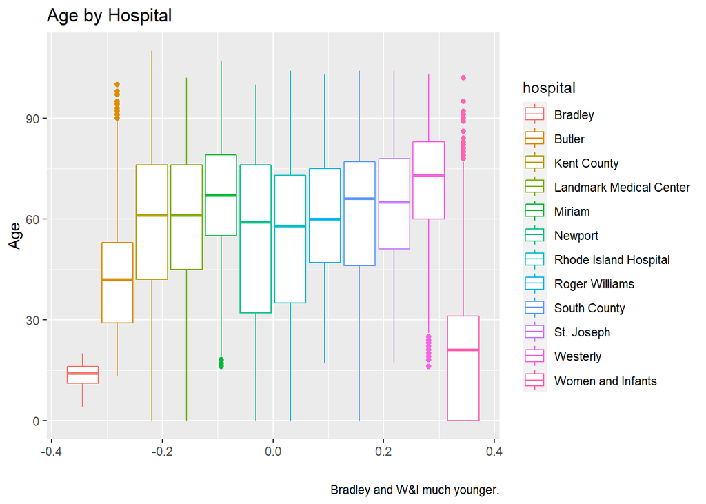

```r
library(tidyverse)
df2 %>% ggplot()+
  geom_boxplot(mapping = aes(y = age, color = hospital))+
    labs(title = 'Age by Hospital', x='', y='Age', fill='Hospital', caption = 'Bradley and W&I much younger.')
```

Bradley and Women and Infants hospitals both seem to have patients that are much younger than average - for Women and Infants this is not a surprise since they have lots of newborn patients. The average age of patients in Butler hospital is also lower than typical at around 43 instead of being around 60.

#### Sex by Hospital (2):

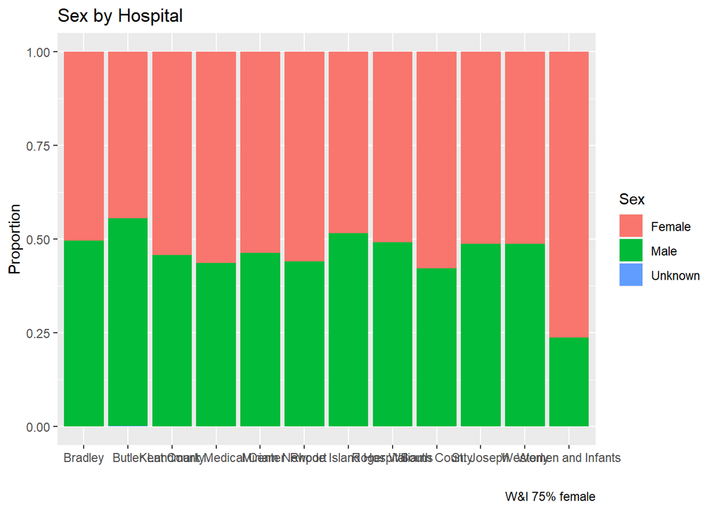

```r
df2 %>% ggplot()+geom_bar(mapping=aes(x=hospital, fill=SEX2),
           position = 'fill')+
    labs(title = 'Sex by Hospital', x='', y='Proportion', fill='Sex', caption = 'W&I 75% female')
```

About 75% of the patients at Women and Infants are female, while most of the other hospitals are close to a 50/50 split.

#### Age by Campus (3):

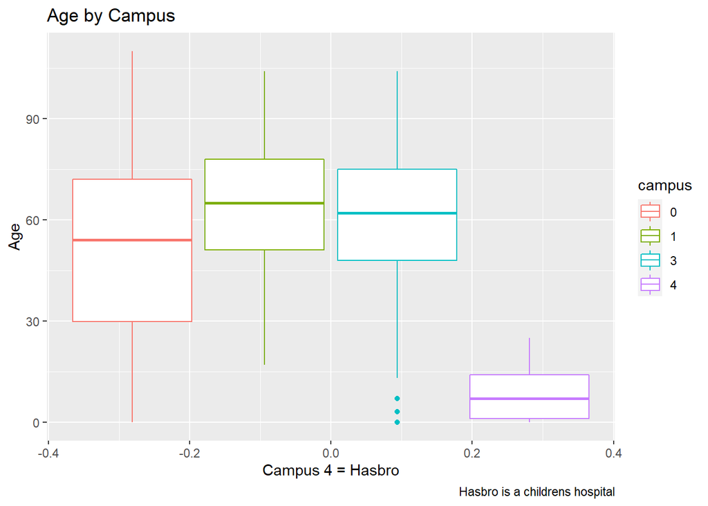

```r
df2$campus <- as.factor(df2$campus)
df2 %>% ggplot()+
  geom_boxplot(mapping = aes(y = age, color = campus))+
    labs(title = 'Age by Campus', x='Campus 4 = Hasbro', y='Age', fill='Campus', caption = 'Hasbro is a childrens hospital')
```

Most hospitals only have one campus (indicated by campus = 0), but it was interesting to note that campus 4 (Hasbro) has much younger patients. This makes sense because Hasbro is a Children’s hospital and does not treat older patients (the eldest patient appears to be about 25 years old or so).

#### Type of Admittance by Hospital (4):

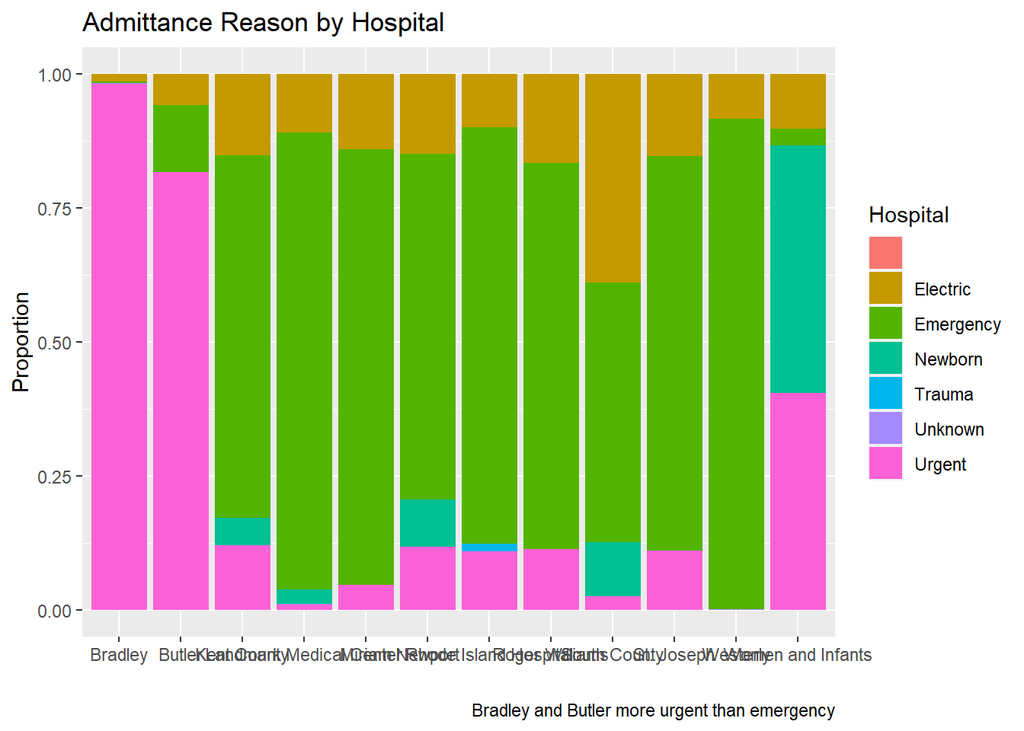

```r
df2 %>% ggplot()+geom_bar(mapping=aes(x=hospital, fill=Admit2),position = 'fill')+
    labs(title = 'Admittance Reason by Hospital', x='', y='Proportion', fill='Hospital', caption = 'Bradley and Butler more urgent than emergency')
```

Bradley and Butler both seem to have many more patients designated as *urgent* than *emergency*, which may have something to do with the fact that those two hospitals tend to focus on psychiatric needs and mental health. The only other hospital to note is Women and Infants which has a large proportion of newborns for their patients and very few emergencies.

#### Total ICU Days by Hospital (5):

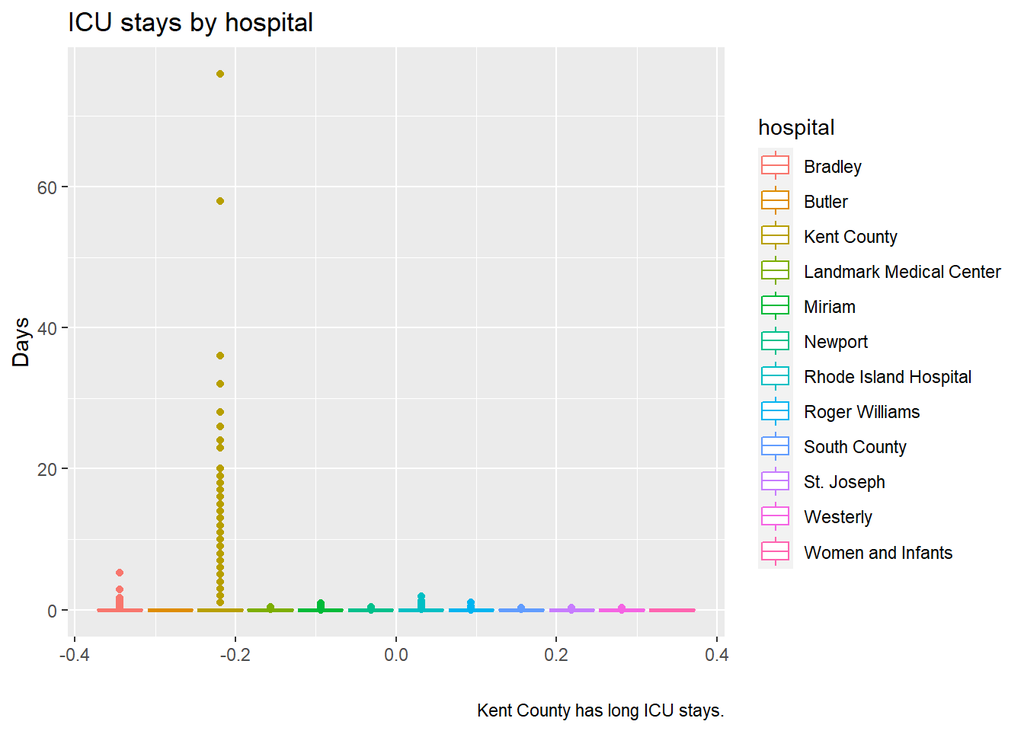

```r
library(ggplot2)
df2$icu <-as.numeric(df2$icu)
df2$icu <- as.numeric(df2$icu/100)
df2 %>% ggplot()+
  geom_boxplot(mapping = aes(y = icu, color = hospital)) + labs(title = 'ICU stays by hospital', x='', y='Days', fill='Hospital', caption = 'Kent County has long ICU stays.')
```

It seems that the Kent County Hospital has the longest icu stays for patients. Perhaps the hospital is better equipped to help patients that need intensive care than other Rhode Island hospitals.

### What makes patients stay longer?

#### Distribution of Length of Stay (6):

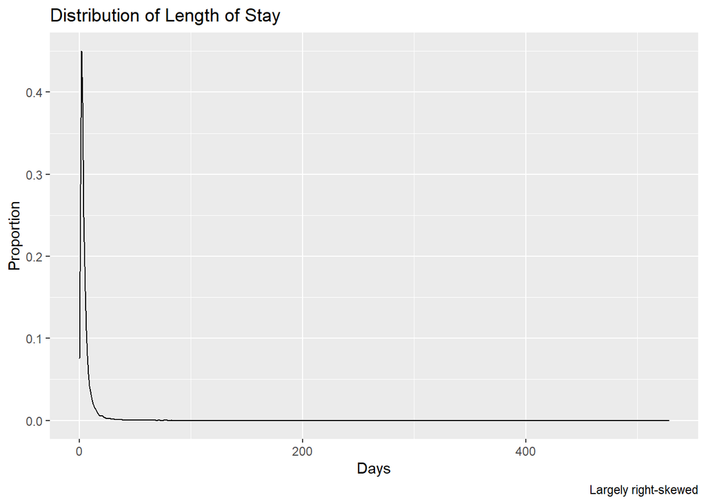

```r
df2 %>% ggplot()+
  geom_density(mapping = aes(x = los)) + labs(title = 'Distribution of Length of Stay', x='Days', y='Proportion', caption = 'Largely right-skewed')
```

Most stays are for only a few days, but there are a few patients who stayed in the hospital for a very long time.

#### Impact of Race and Age on Length of Stay (7):

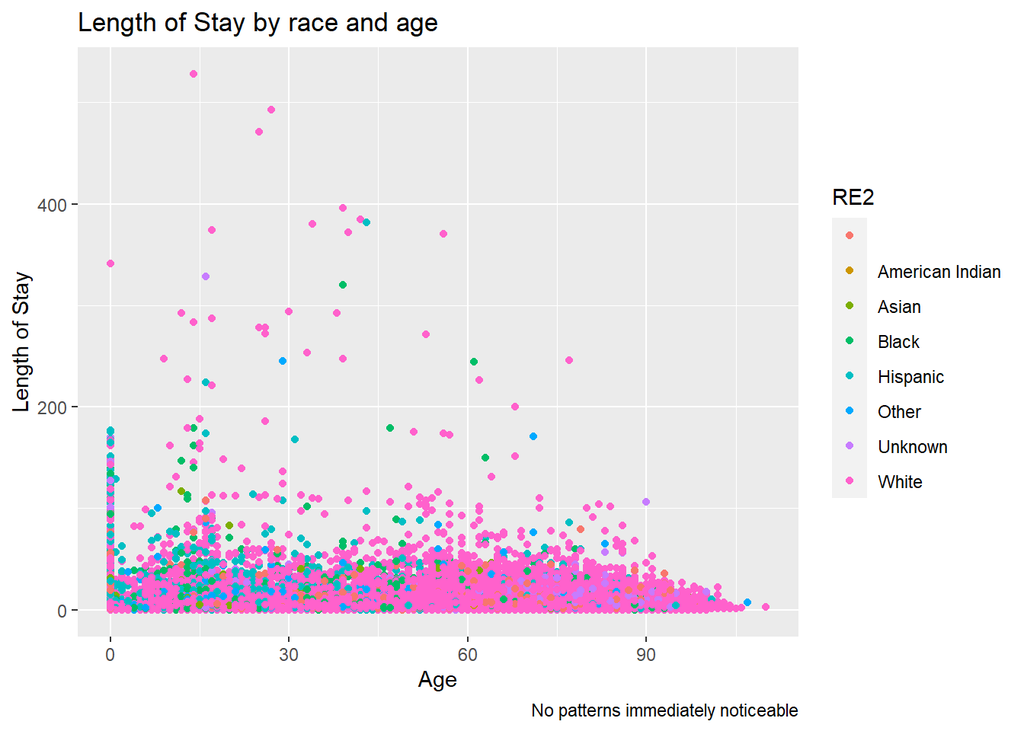

```r
df2  %>% ggplot()+
  geom_point(mapping = aes(x = age, y = los, color = RE2)) + labs(title = 'Length of Stay by race and age', x='Age', y='Length of Stay', caption = 'No patterns immediately noticeable')
```

There does not appear to be much of an impact from either age or race and ethnicity on length of stay.

#### Cost by Length of Stay by Sex (8):

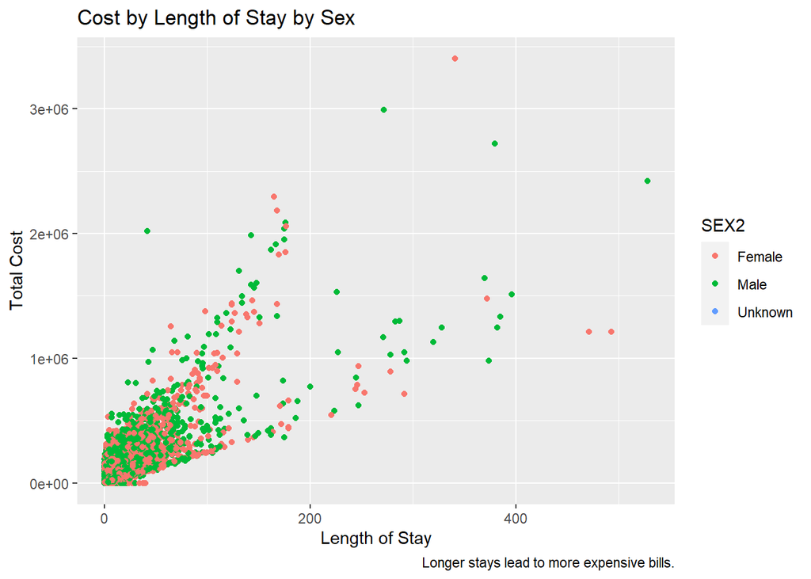

```r
df2  %>% ggplot()+
  geom_point(mapping = aes(x = los, y = tot, color = SEX2)) + labs(title = 'Cost by Length of Stay by Sex', x='Length of Stay', y='Total Cost', fill='Sex', caption = 'Longer stays lead to more expensive bills.')
```

Longer stays are more expensive (somewhat of an obvious conclusion). It also appears that men and women pay around the same amount for a given length of stay and that men and women stay in the hospital for similar lengths of time.

#### Length of Stay by Hospital (9):

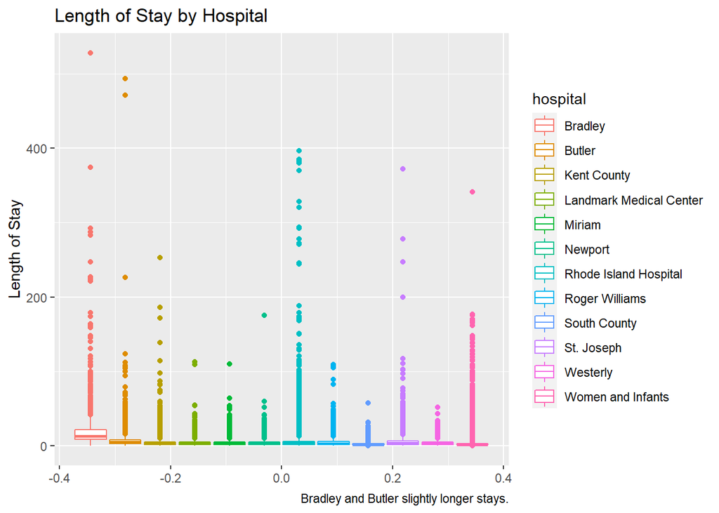

```r
df2  %>% ggplot()+
  geom_boxplot(mapping = aes(y = los, color = hospital)) + labs(title = 'Length of Stay by Hospital', y='Length of Stay', fill='Hospital', caption = 'Bradley and Butler slightly longer stays.')
```

#### Length of Stay by Hospital B(9B):

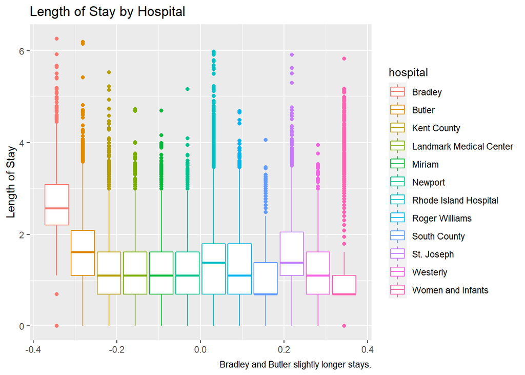

```r
df2  %>% ggplot()+
  geom_boxplot(mapping = aes(y = log(los), color = hospital)) + labs(title = 'Length of Stay by Hospital', y='Length of Stay', fill='Hospital', caption = 'Bradley and Butler slightly longer stays.')
```

Bradley and Butler have longer stays on average compared to other hospitals (even though it is a bit difficult to tell in the graphic). They also have the longest outlier stays, although Rhode Island Hospital also has a few long-term patients.

### What impacts birth weight?

#### Birth weight by month by hospital (10):

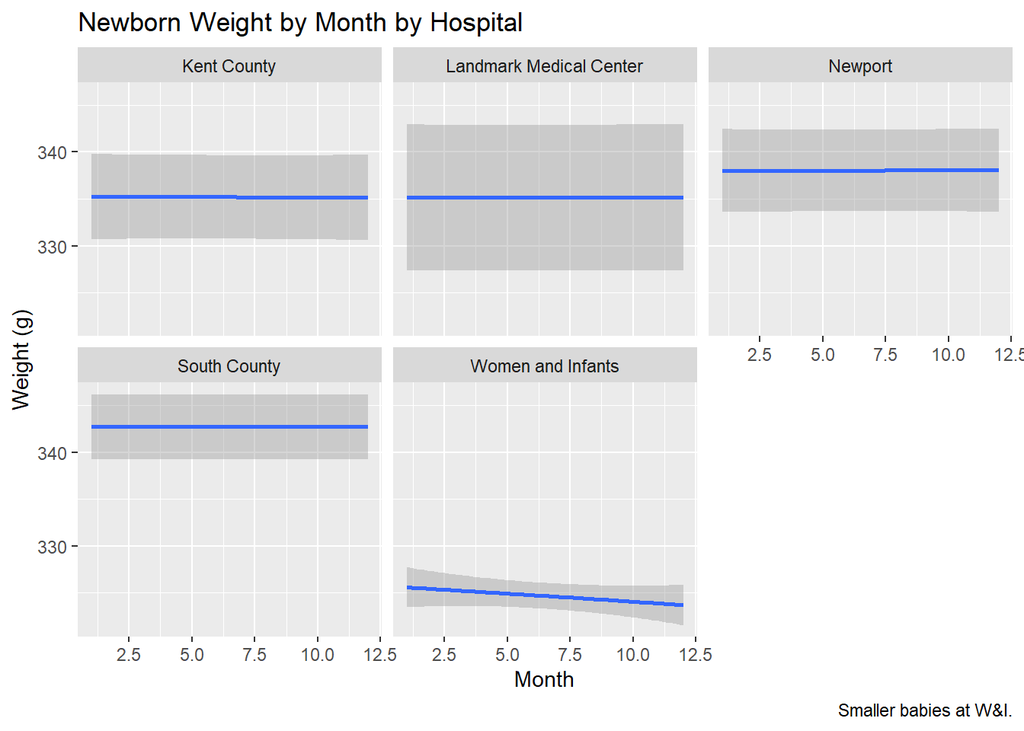

```r
df2$b_wt <- as.numeric(df2$b_wt)
df2 %>%  filter(b_wt>0) %>%  filter(Admit2 =='Newborn')%>% ggplot() + geom_smooth(mapping=aes(x=moa, y=b_wt)) + facet_wrap(vars(hospital)) + labs(title = 'Newborn Weight by Month by Hospital', x='Month', y='Weight (g)', caption = 'Smaller babies at W&I.')
```

Most babies are born with a weight of around 335g, but babies at Women and Infants are significantly smaller on average (and babies born at South County hospital are larger). There does not appear to be any pattern to babies being heavier or lighter in any given month.

#### Birth weight by race and sex (11):

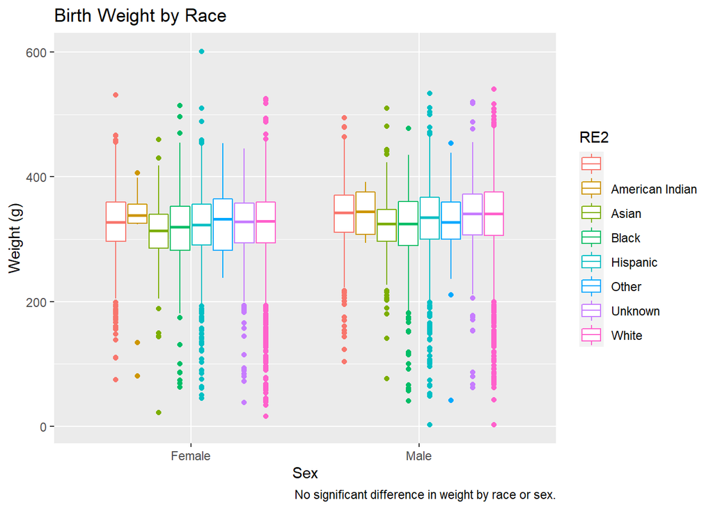

```r
df2 %>%  filter(b_wt>0) %>% filter(SEX2 !='Unknown') %>% ggplot()+
  geom_boxplot(mapping = aes(x=SEX2, y = b_wt, color = RE2)) + labs(title = 'Birth Weight by Race', x='Sex', y='Weight (g)', fill='Race/Ethnicity', caption = 'No significant difference in weight by race or sex.')
```

Race and sex have little impact on a baby’s birth weight according to the graph.

### Which hospitals cost the most?

#### Histogram of Total Cost (12):

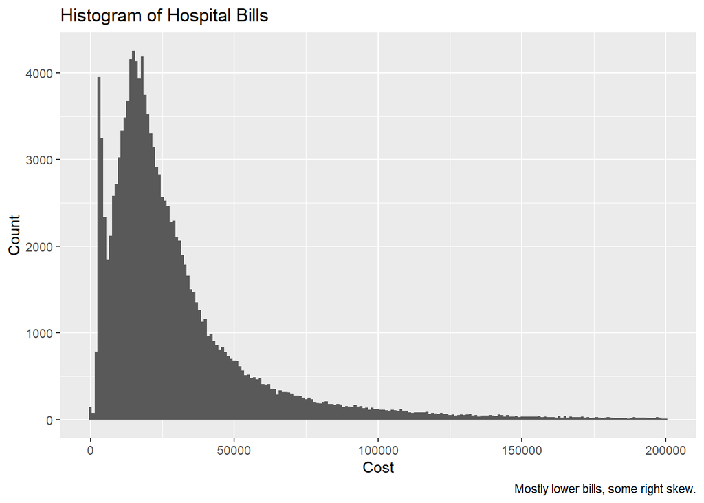

```r
df2 %>% filter (tot <=200000) %>% ggplot()+
  geom_histogram(binwidth = 1000, mapping = aes(x = tot)) + labs(title = 'Histogram of Hospital Bills', x='Cost', y='Count', caption = 'Mostly lower bills, some right skew.')
```

Some excessively large bills were omitted so that the graph would better display the results. Most bills fall under $35,000 or so, but some bills are very large, leading to a right skew in the histogram.

#### Average Cost by Hospital (13):

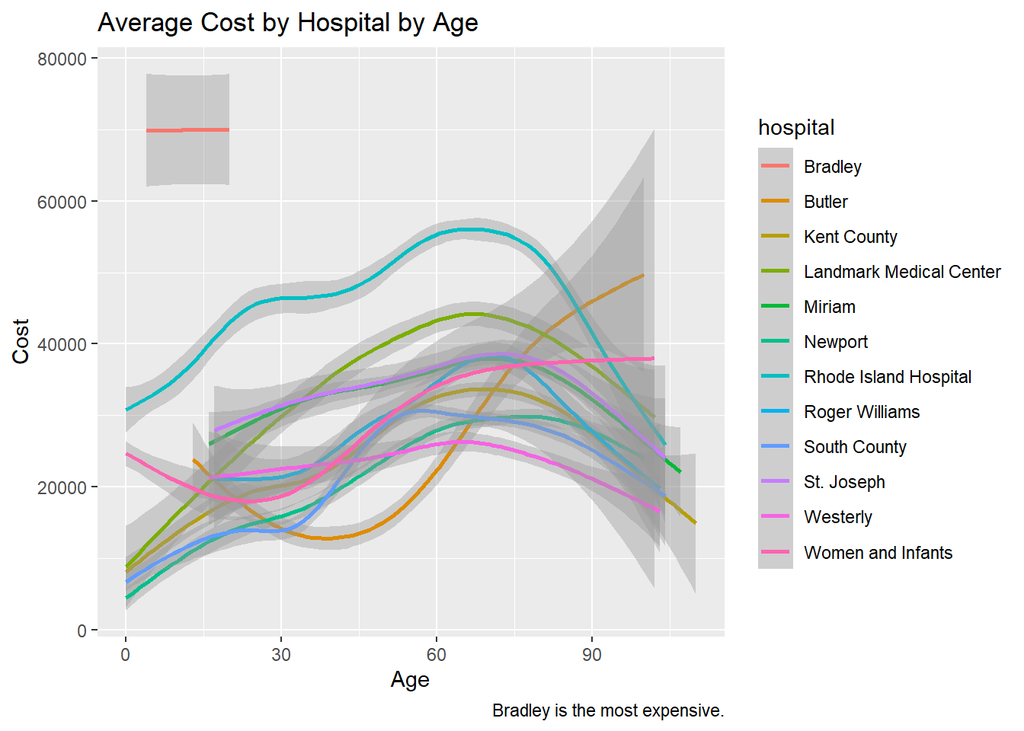

```r
df2 %>% ggplot()+geom_smooth(mapping = aes(x = age, y = tot, color = hospital)) + labs(title = 'Average Cost by Hospital by Age', x='Age', y='Cost', caption = 'Bradley is the most expensive.')
```

Bradley is the most expensive hospital by a large margin, and the next most expensive provider is Rhode Island Hospital. It seems like middle-aged people typically pay more than either younger or older patients based on the mostly parabolic curves (Butler follows the opposite pattern).